# Homework_MD_05

```r
library(tidyverse)

twitch_data <- read_csv("https://raw.githubusercontent.com/vaiseys/dav-course/main/Data/twitchdata-update.csv")
```

I installed the janitor package in the console.

```r
library(janitor)
twitch_data <- clean_names(twitch_data)

# Inspect new names
colnames(twitch_data)
```

```
 [1] "channel"             "watch_time_minutes"  "stream_time_minutes"
 [4] "peak_viewers"        "average_viewers"     "followers"
 [7] "followers_gained"    "views_gained"        "partnered"
[10] "mature"              "language"
```

## Question 1

```r
library(tidyverse)
library(moderndive)
library(skimr)
```

I loaded some packages I might need.

```r
evals_ch5 <- twitch_data %>%
  sample_n(size = 5) %>%
  select(channel, average_viewers, followers)
evals_ch5
```

```
# A tibble: 5 × 3
  channel            average_viewers followers
  <chr>                        <dbl>     <dbl>
1 악어 (jdm2088)               15405    276488
2 wingz                         1347     85695
3 スタンミ (sutanmi)            2683     53124
4 orangemorange                 2653    261139
5 SilentSentry                  1085    301633
```

```r
summ_eval <- twitch_data %>%
  select(average_viewers, followers) %>%
  summary()
summ_eval
```

```
 average_viewers    followers
 Min.   :   235   Min.   :   3660
 1st Qu.:  1458   1st Qu.: 170546
 Median :  2425   Median : 318063
 Mean   :  4781   Mean   : 570054
 3rd Qu.:  4786   3rd Qu.: 624332
 Max.   :147643   Max.   :8938903
```

The mean of the average viewers is much lower than the mean followers. This shows that even though each channel has many followers, most of the followers are not viewing the channel.

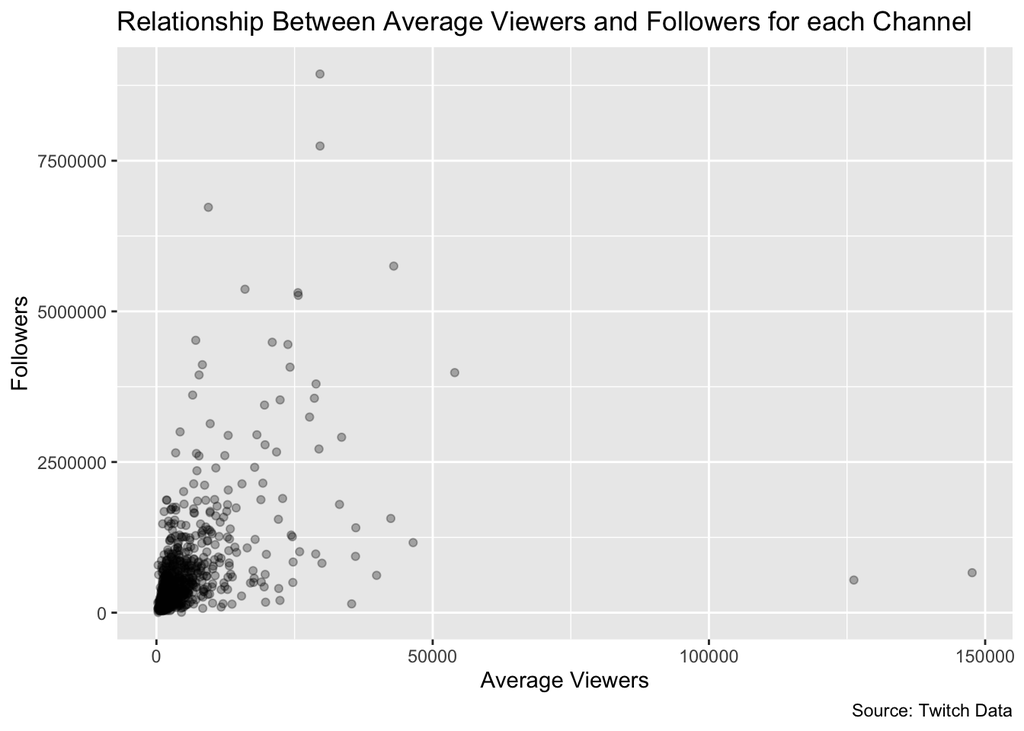

```r
view_follow <- ggplot(twitch_data,
                aes(x = average_viewers, y = followers)) +
  geom_jitter(alpha = 0.3) +
  labs(x = "Average Viewers", y = "Followers", title = "Relationship Between Average Viewers and Followers for each Channel", caption = "Source: Twitch Data")
view_follow
```

I notice that the majority of data is packed between 0-25,000 average viewers and 0-1,250,000 followers.

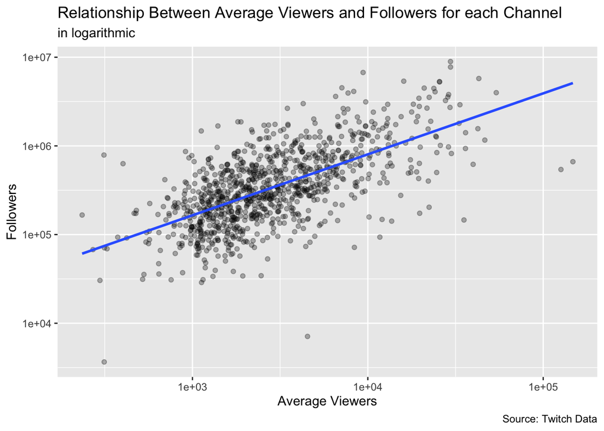

```r
view_follow <- ggplot(twitch_data,
                aes(x = average_viewers, y = followers)) +
  geom_jitter(alpha = 0.3) +
  labs(x = "Average Viewers", y = "Followers", title = "Relationship Between Average Viewers and Followers for each Channel", subtitle = "in logarithmic",  caption = "Source: Twitch Data") +
  scale_x_log10() +
  scale_y_log10() +
  geom_smooth(method = "lm", se = FALSE)
view_follow
```

I notice a positive correlation between the average viewers and the number of followers. As the number of followers increase, the average viewers increase too.

```r
twitch_data <- twitch_data %>%
  mutate(log_viewers = log10(average_viewers),
         log_followers = log10(followers))
```

## Question 2

```r
fit1 <- lm(log_viewers ~ log_followers, data = twitch_data)
```

I installed the broom package in the console.

```r
library(broom)
tidy(fit1)
```

```
# A tibble: 2 × 5
  term          estimate std.error statistic   p.value
  <chr>            <dbl>     <dbl>     <dbl>     <dbl>
1 (Intercept)      0.198    0.125       1.58 1.15e-  1
2 log_followers    0.588    0.0226     26.0  1.69e-114
```

A 10% increase in followers is associated with a 5.8% increase in the average number of viewers.

## Question 3

```r
pred_data <- augment(fit1)

# glimpse our new data
glimpse(pred_data)
```

```
Rows: 1,000
Columns: 8
$ log_viewers   <dbl> 4.442731, 4.408410, 4.040444, 3.887280, 4.471321, 4.6275…
$ log_followers <dbl> 6.511388, 6.725108, 6.247393, 6.596030, 6.951284, 6.1940…
$ .fitted       <dbl> 4.029761, 4.155534, 3.874400, 4.079572, 4.288638, 3.8430…
$ .resid        <dbl> 0.4129697, 0.2528757, 0.1660436, -0.1922928, 0.1826833, …
$ .hat          <dbl> 0.006194481, 0.008694557, 0.003782169, 0.007126066, 0.01…
$ .sigma        <dbl> 0.3085580, 0.3087321, 0.3087919, 0.3087764, 0.3087820, 0…
$ .cooksd       <dbl> 0.0056128779, 0.0029688873, 0.0005513456, 0.0014026033, …
$ .std.resid    <dbl> 1.3420109, 0.8227954, 0.5389316, -0.6251793, 0.5953620, …
```

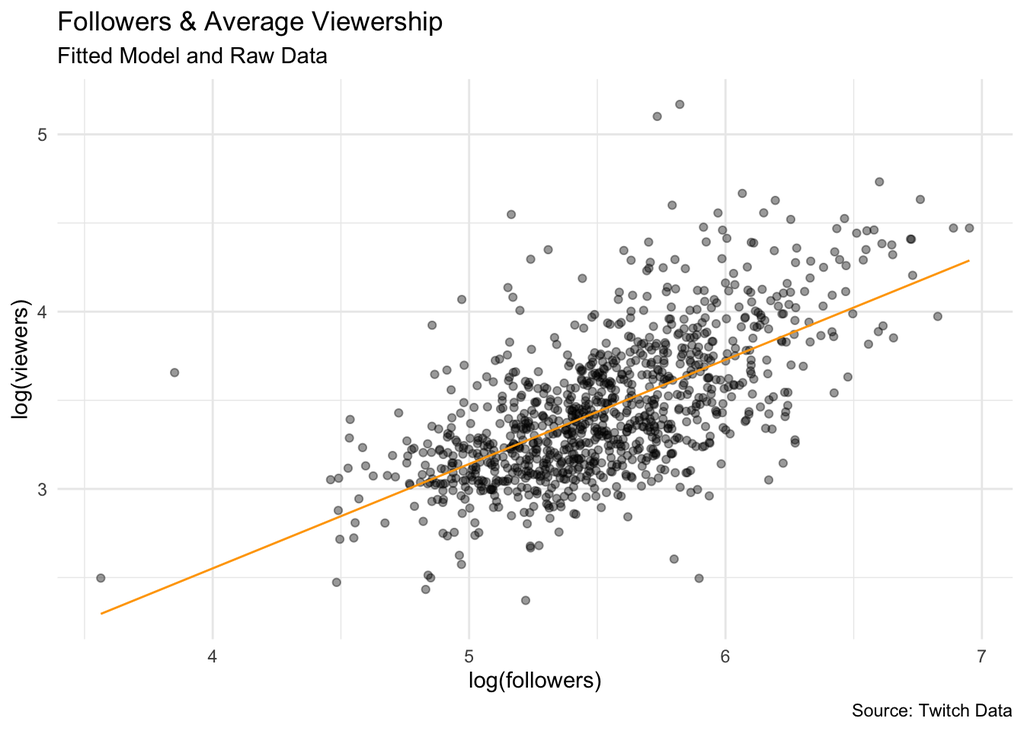

```r
pred_data %>%
  ggplot(aes(x = log_followers,
             y = log_viewers)) +
  geom_jitter(alpha = 0.4) +
  geom_line(aes(x = log_followers,
                y = .fitted),
            col = "orange") +
  theme_minimal() +
  labs(subtitle = "Fitted Model and Raw Data",
       title = "Followers & Average Viewership",
       caption = "Source: Twitch Data",
       x = "log(followers)",
       y = "log(viewers)")
```

I think the model displays the relationship fairly well between the followers and viewers. The graph shows that with one unit increase of followers in the logarithmic value is roughly a 0.6 unit increase of viewers in the logarithmic value. Some of the points are bunched around the line far away. So I believe a rough trend could be analyzed using the plot, but not a very accurate representation of the relationship between followers and viewers.

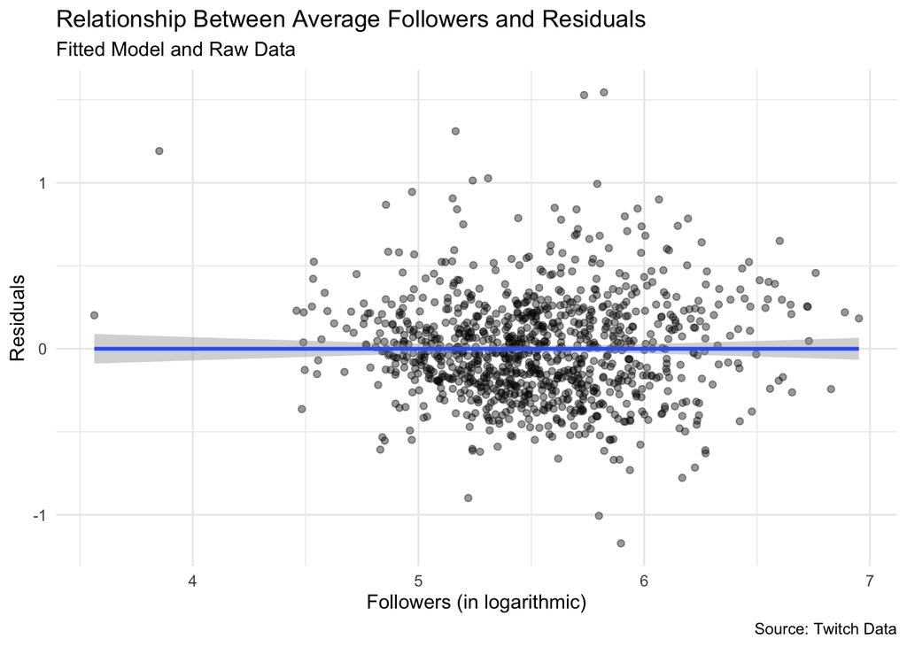

```r
pred_data %>%
  ggplot(aes(x = log_followers,
             y = .resid)) +
  geom_jitter(alpha = 0.4) +
  geom_smooth(method = "lm") +
  theme_minimal() +
  labs(subtitle = "Fitted Model and Raw Data", title = "Relationship Between Average Followers and Residuals", x = "Followers (in logarithmic)", y = "Residuals", caption = "Source: Twitch Data")
```

There is an outlier observed value near 3.5 followers (in logarithmic value) that is near my predicted value. I notice that between 4.5 and 7 followers (in logarithmic values), the observed values are both above and below my predicted fitted value. This is where the big residuals occur. There are also points between these x-values that are close to my predicted value, but the system did fail to predict a majority of the data.

## Question 4

```r
evals2 <- twitch_data %>%
  sample_n(size = 8) %>%
  select(average_viewers, language)
evals2
```

```
# A tibble: 8 × 2
  average_viewers language
            <dbl> <chr>
1            2635 English
2            2984 English
3            1030 Turkish
4           19495 Russian
5            1186 English
6            1264 English
7            1388 English
8            3926 English
```

```r
summ2 <- twitch_data %>%
  select(average_viewers, language) %>%
  summary()
summ2
```

```
 average_viewers    language
 Min.   :   235   Length:1000
 1st Qu.:  1458   Class :character
 Median :  2425   Mode  :character
 Mean   :  4781
 3rd Qu.:  4786
 Max.   :147643
```

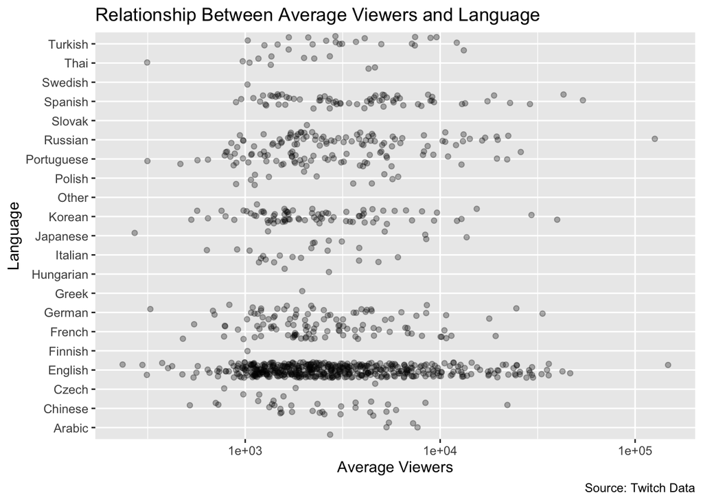

```r
lang_view <- ggplot(twitch_data,
                aes(x = language, y = average_viewers)) +
  geom_jitter(alpha = 0.3) +
  labs(x = "Language", y = "Average Viewers", title = "Relationship Between Average Viewers and Language", caption = "Source: Twitch Data") +
  coord_flip() +
  scale_y_log10()
lang_view
```

Based on the plot, it shows that English has the most average viewers.

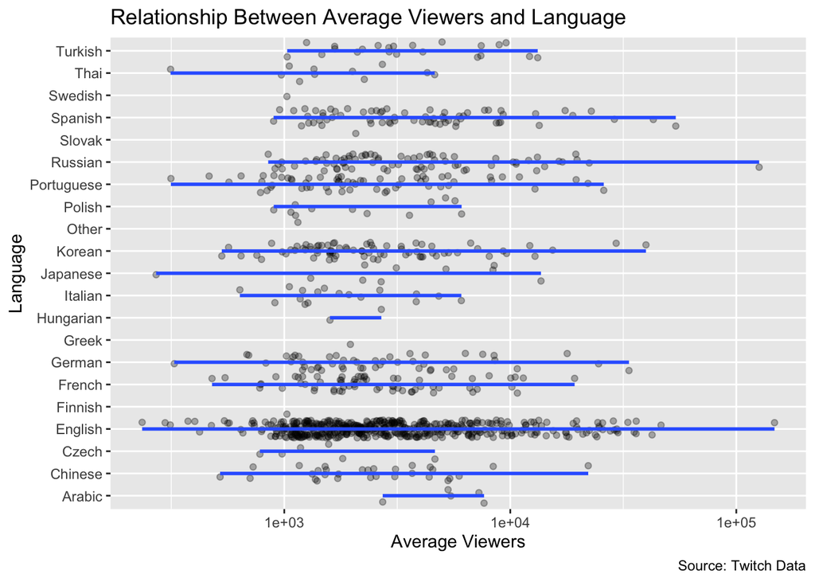

```r
lang_view <- ggplot(twitch_data,
                aes(x = average_viewers, y = language)) +
  geom_jitter(alpha = 0.3) +
  labs(y = "Language", x = "Average Viewers", title = "Relationship Between Average Viewers and Language", caption = "Source: Twitch Data") +
  scale_x_log10() +
  geom_smooth(method = "lm", se = FALSE)
lang_view
```

I am not sure if the geom_smooth() method was efficient here because it develops a line of trend for each individual language.

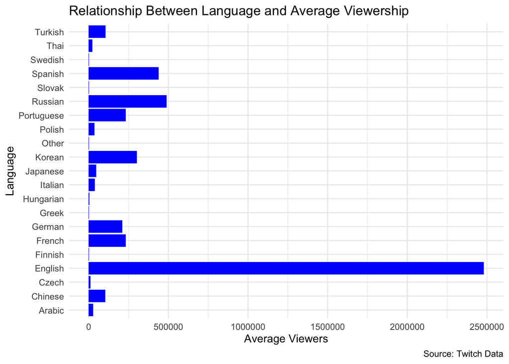

```r
ggplot(twitch_data,
       aes(x = language, y = average_viewers)) +
  labs(x = "Language",
       y = "Average Viewers",
       title = "Relationship Between Language and Average Viewership",
       caption = "Source: Twitch Data") +
  geom_col(fill = "blue") +
  theme_minimal() +
  coord_flip()
```

## Question 5

```r
twitch_data <- twitch_data %>%
  mutate(language = as.factor(language),
         language = relevel(language, ref = "English"))
```

```r
fit2 <- lm(average_viewers ~ language, data = twitch_data)

get_regression_table(fit2)
```

```
# A tibble: 21 × 7
   term                estimate std_error statistic p_value lower_ci upper_ci
   <chr>                  <dbl>     <dbl>     <dbl>   <dbl>    <dbl>    <dbl>
 1 intercept              5113.      385.    13.3     0        4358.    5868.
 2 language: Arabic        569.     3808.     0.15    0.881   -6903.    8042.
 3 language: Chinese     -1688.     1594.    -1.06    0.29    -4815.    1439.
 4 language: Czech       -3285.     3480.    -0.944   0.345  -10113.    3543.
 5 language: Finnish     -4086.     8480.    -0.482   0.63   -20726.   12555.
 6 language: French      -1606.     1111.    -1.44    0.149   -3787.     575.
 7 language: German       -835.     1270.    -0.657   0.511   -3326.    1657.
 8 language: Greek       -3152.     8480.    -0.372   0.71   -19792.   13489.
 9 language: Hungarian   -2972.     6002.    -0.495   0.621  -14751.    8806.
10 language: Italian     -2907.     2090.    -1.39    0.165   -7009.    1194.
# ℹ 11 more rows
```

English was used as the reference variable. Arabic, Russian, and Spanish are the language with positive coefficients, demonstrating that they have more average viewers than the English language. The rest of the languages have a negative coefficient, demonstrating that they have less average viewers than the English language. So the English language does have higher average viewership than a majority of the other languages.

## Question 6

```r
pred_data2 <- augment(fit2)
```

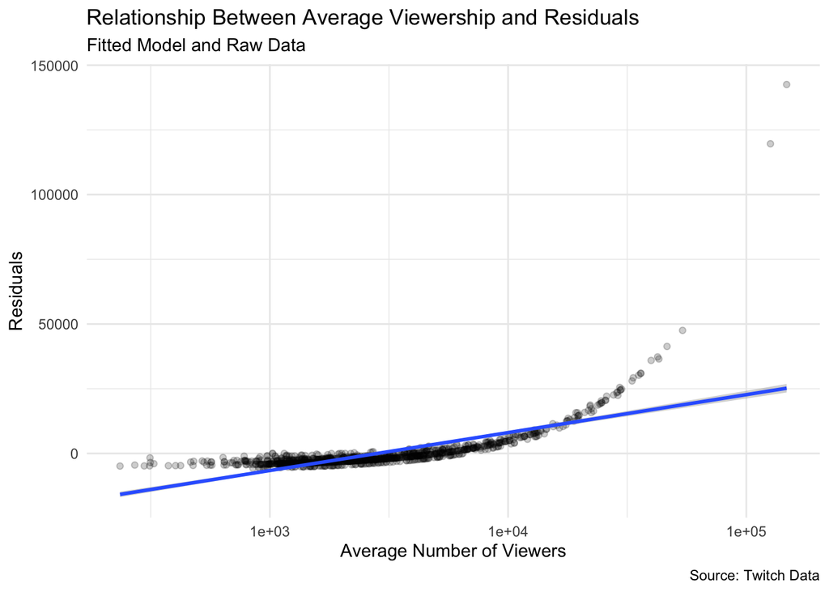

```r
pred_data2 %>%
  ggplot(aes(x = average_viewers,
             y = .resid)) +
  geom_jitter(alpha = 0.2) +
  geom_smooth(method = "lm") +
  scale_x_log10()+
  theme_minimal() +
  labs(subtitle = "Fitted Model and Raw Data", title = "Relationship Between Average Viewership and Residuals", x = "Average Number of Viewers", y = "Residuals", caption = "Source: Twitch Data")
```

```r
largest_out <-get_regression_points(fit2) %>%
  arrange(desc(residual))
largest_out
```

```
# A tibble: 1,000 × 5
      ID average_viewers language average_viewers_hat residual
   <int>           <dbl> <fct>                  <dbl>    <dbl>
 1    82          147643 English                5113.  142530.
 2   110          126232 Russian                6594.  119638.
 3    15           53986 Spanish                6450.   47536.
 4    42           46459 English                5113.   41346.
 5     6           42414 English                5113.   37301.
 6    14           42948 Spanish                6450.   36498.
 7    22           39848 Korean                 3914.   35934.
 8    53           36086 English                5113.   30973.
 9    47           36030 English                5113.   30917.
10   991           35333 English                5113.   30220.
# ℹ 990 more rows
```

Also, there are two outliers that are very far from the predicted model, so there is a large residual near the end of the model. These are two points the graph missed. They are ID 82 (English language) and ID 110 (Russian) with average viewership of 147,643 (residual:142530.186) and 126,232 (residual:119637.770), respectively.